# Project

Dr. B

October 7, 2015

## Codebook

After a review of the various code books available for the class, I decided to use the Gapminder data set.

## Question

Is there an association between Internet usage and suicide rates? I will use the variables Internetuserate and suicideper100TH rate in my code book.

## Literature Review

There is concern that the Internet is playing an increasing role in self-harm and suicide. Internet use may exert both positive and negative effects on young people at risk of self-harm or suicide. The internet has created channels of communication that can be misused to ‘cyber-bully’ peers; both cyber-bullying and general internet use have been found to correlate with increased risk of self-harm, suicidal idealization, and depression. Youth who self-harm or are suicidal often make use of the internet. It is most commonly used for constructive reasons such as seeking support and coping strategies, but may exert a negative influence, normalizing self-harm and potentially discouraging disclosure or professional help-seeking. Correlations have been found between internet exposure and violent methods of self-harm.

Baker D, & Fortune S (2008) Understanding self-harm and suicide websites a qualitative interview study of young adult website users. Crisis 29: 118-122.

Daine K, Hawton K, Singaravelu V, Stewart A, Simkin S, Montgomery P (2013) The Power of the Web: A Systematic Review of Studies of the Influence of the Internet on Self-Harm and Suicide in Young People. PLoS ONE 8(10): e77555. doi:10.1371/journal.pone.0077555

Dunlop SM, More E, Romer D (2011) Where do youth learn about suicides on the Internet, and what influence does this have on suicidal ideation? J Child Psychol Psychiatry 52: 1073-1080.

Durkee T, Hadlaczky G, Westerlund M, Carli V (2011) Internet pathways in suicidality: A review of the evidence. IntJEnvironResPublic Health 8: 3938- 3952.

Gould MS, Wallenstein S, Kleinman MH, O’Carroll P, Mercy J (1990) Suicide clusters: an examination of age-specific effects. Am J Public Health 80: 211-212.

Hawton K, Saunders KEA, O’Connor RC (2012) Self-harm and suicide in adolescents. Lancet 379: 2373-2382.

Kim K, Ryu E, Chon MY, Yeun EJ, Choi SY, et al. (2006) Internet addiction in Korean adolescents and its relation to depression and suicidal ideation: A questionnaire survey. Int J Nurs Stud 43: 185-192.

Katsumata Y, Matsumoto T, Kitani M, Takeshima T (2008) Electronic media use and suicidal ideation in Japanese adolescents. Psychiatry Clin Neurosci 62: 744-746.

Madge N, Hawton K, McMahon EM, De Leo D, de Wilde EJ, et al. (2011) Psychological characteristics, stressful life events and deliberate self-harm: findings from the Child & Adolescent Self-harm in Europe (CASE) Study. Eur Child Adolesc Psychiatry 20: 499-508.

O’Connor RC, Rasmussen S, Hawton K (2012) Distinguishing adolescents who think about self-harm from those who engage in self-harm. Br J Psychiatry 200: 330-335.

Patton GC, Coffey C, Sawyer SM, Viner RM, Haller DM, et al. (2009) Global patterns of mortality in young people: a systematic analysis of population health data. Lancet 374: 881-892.

## Hypothesis

There is a positive relationship between Internet usage rates and suicide rates.

## Summary of All Variables

Below are variable names and summaries of all the variables in the data set

```
##  [1] "country"              "incomeperperson"      "alcconsumption"
##  [4] "armedforcesrate"      "breastcancerper100th" "co2emissions"
##  [7] "femaleemployrate"     "hivrate"              "internetuserate"
## [10] "lifeexpectancy"       "oilperperson"         "polityscore"
## [13] "relectricperperson"   "suicideper100th"      "employrate"
## [16] "urbanrate"
```

```
##                 country    incomeperperson     alcconsumption
##  Afghanistan        :  1   Min.   :   103.78   Min.   : 0.0300
##  Albania            :  1   1st Qu.:   748.25   1st Qu.: 2.6250
##  Algeria            :  1   Median :  2553.50   Median : 5.9200
##  Andorra            :  1   Mean   :  8740.97   Mean   : 6.6894
##  Angola             :  1   3rd Qu.:  9379.89   3rd Qu.: 9.9250
##  Antigua and Barbuda:  1   Max.   :105147.44   Max.   :23.0100
##  (Other)            :207   NA's   :23          NA's   :26
##  armedforcesrate    breastcancerper100th  co2emissions
##  Min.   : 0.00000   Min.   :  3.900      Min.   :      132000
##  1st Qu.: 0.48091   1st Qu.: 20.600      1st Qu.:    34846167
##  Median : 0.93064   Median : 30.000      Median :   185901833
##  Mean   : 1.44402   Mean   : 37.403      Mean   :  5033261622
##  3rd Qu.: 1.61138   3rd Qu.: 50.300      3rd Qu.:  1846084167
##  Max.   :10.63852   Max.   :101.100      Max.   :334220872333
##  NA's   :49         NA's   :40           NA's   :13
##  femaleemployrate    hivrate        internetuserate    lifeexpectancy
##  Min.   :11.300   Min.   : 0.0600   Min.   : 0.21007   Min.   :47.794
##  1st Qu.:38.725   1st Qu.: 0.1000   1st Qu.: 9.99960   1st Qu.:64.447
##  Median :47.550   Median : 0.4000   Median :31.81012   Median :73.131
##  Mean   :47.549   Mean   : 1.9354   Mean   :35.63272   Mean   :69.754
##  3rd Qu.:55.875   3rd Qu.: 1.3000   3rd Qu.:56.41605   3rd Qu.:76.593
##  Max.   :83.300   Max.   :25.9000   Max.   :95.63811   Max.   :83.394
##  NA's   :35       NA's   :66        NA's   :21         NA's   :22
##   oilperperson        polityscore       relectricperperson
##  Min.   : 0.032281   Min.   :-10.0000   Min.   :    0.00
##  1st Qu.: 0.532541   1st Qu.: -2.0000   1st Qu.:  203.65
##  Median : 1.032470   Median :  6.0000   Median :  597.14
##  Mean   : 1.484085   Mean   :  3.6894   Mean   : 1173.18
##  3rd Qu.: 1.622737   3rd Qu.:  9.0000   3rd Qu.: 1491.15
##  Max.   :12.228645   Max.   : 10.0000   Max.   :11154.75
##  NA's   :150         NA's   :52         NA's   :77
##  suicideper100th      employrate       urbanrate
##  Min.   : 0.20145   Min.   :32.000   Min.   : 10.400
##  1st Qu.: 4.98845   1st Qu.:51.225   1st Qu.: 36.830
##  Median : 8.26289   Median :58.700   Median : 57.940
##  Mean   : 9.64084   Mean   :58.636   Mean   : 56.769
##  3rd Qu.:12.32855   3rd Qu.:64.975   3rd Qu.: 74.210
##  Max.   :35.75287   Max.   :83.200   Max.   :100.000
##  NA's   :22         NA's   :35       NA's   :10
```

## Data Analysis

### Countries by Internet Use Rates

Top users

```
## Source: local data frame [40 x 2]
##
##           country       Max
##            (fctr)     (dbl)
## 1         Iceland 95.638113
## 2          Norway 93.277508
## 3     Netherlands 90.703555
## 4      Luxembourg 90.079527
## 5          Sweden 90.016190
## 6         Denmark 88.770254
## 7         Finland 86.898845
## 8  United Kingdom 84.731705
## 9         Bermuda 84.654514
## 10    New Zealand 83.002584
## ..            ...       ...
```

Bottom users

```
## Source: local data frame [40 x 2]
##
##                 country       Max
##                  (fctr)     (dbl)
## 1            Mauritania 2.9998032
## 2                  Mali 2.6999664
## 3         Cote d'Ivoire 2.5999737
## 4                  Iraq 2.4719483
## 5         Guinea-Bissau 2.4503622
## 6  Central African Rep. 2.3000267
## 7                Malawi 2.2599759
## 8          Turkmenistan 2.1999978
## 9               Burundi 2.1002127
## 10                 Chad 1.7000315
## ..                  ...       ...
```

### Countries by Suicide Rates

Top suicide rates

```
## Source: local data frame [40 x 2]
##
##        country       Max
##         (fctr)     (dbl)
## 1       Guyana 35.752872
## 2    Lithuania 33.341860
## 3      Somalia 29.864164
## 4    Sri Lanka 28.104046
## 5       Russia 27.874160
## 6      Belarus 26.874690
## 7         Laos 26.219198
## 8   Kazakhstan 25.404600
## 9  Korea, Rep. 22.404560
## 10    Maldives 22.353479
## ..         ...       ...
```

Bottom suicide rates

```
## Source: local data frame [40 x 2]
##
##                country       Max
##                 (fctr)     (dbl)
## 1           Tajikistan 2.6489809
## 2                Qatar 2.5157208
## 3            Guatemala 2.2348960
## 4               Cyprus 2.2061690
## 5  Antigua and Barbuda 2.1618433
## 6              Morocco 2.1094136
## 7              Bolivia 2.0341785
## 8          Philippines 1.9224851
## 9                Egypt 1.7999036
## 10                Peru 1.6589078
## ..                 ...       ...
```

### Frequency Distributions

Internet Usage Rates (N/A’s removed)

```
##          rates2.freq
## [0,10)            49
## [10,20)           27
## [20,30)           17
## [30,40)           18
## [40,50)           25
## [50,60)            9
## [60,70)           14
## [70,80)           15
## [80,90)           13
## [90,100)           5
```

Suicide Rates (N/A’s removed)

```
##         rates3.freq
## [0,5)            49
## [5,10)           65
## [10,15)          51
## [15,20)          12
## [20,25)           6
## [25,30)           6
## [30,35)           1
## [35,40)           1
```

### Visual Displays

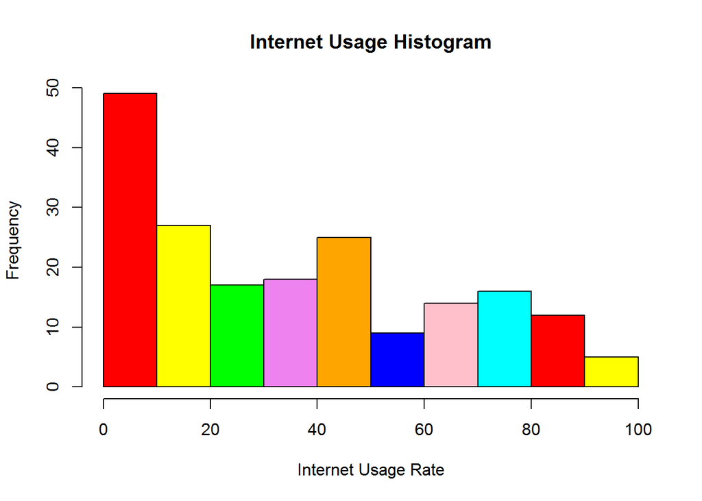

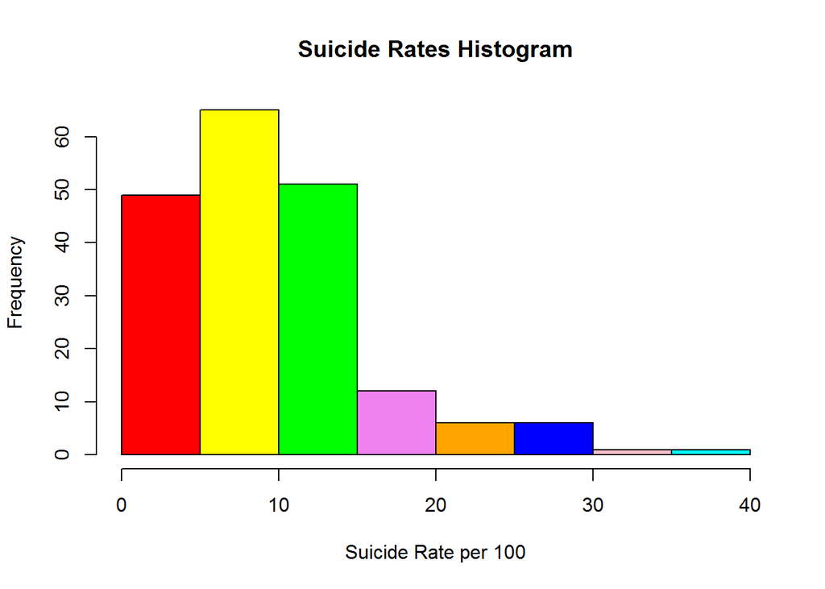

### Assocaition

Regression Model

```
##
## Call:
## lm(formula = df$suicideper100th ~ df$internetuserate)
##
## Residuals:
##     Min      1Q  Median      3Q     Max
## -9.5305 -4.2657 -1.2052  2.8432 26.1621
##
## Coefficients:
##                    Estimate Std. Error t value            Pr(>|t|)
## (Intercept)        9.122301   0.748579 12.1861 <0.0000000000000002 ***
## df$internetuserate 0.015680   0.017207  0.9112              0.3634
## ---
## Signif. codes:  0 '***' 0.001 '**' 0.01 '*' 0.05 '.' 0.1 ' ' 1
##
## Residual standard error: 6.2887 on 175 degrees of freedom
##   (36 observations deleted due to missingness)
## Multiple R-squared:  0.0047223,  Adjusted R-squared:  -0.00096502
## F-statistic: 0.83032 on 1 and 175 DF,  p-value: 0.36343
```

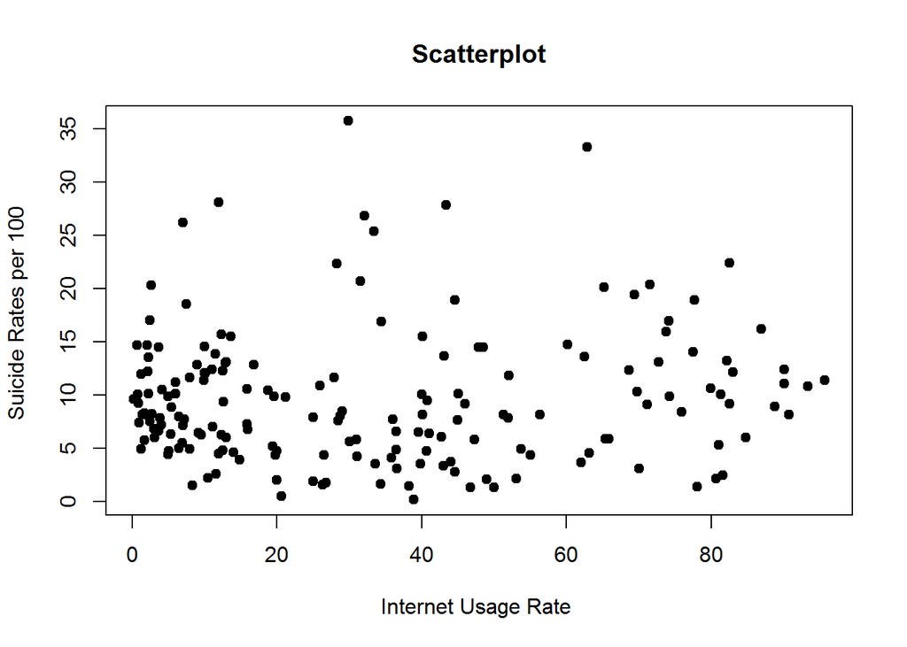